# Explicacion aplicacion

Willmer

25/10/2020

### TABLERO PRUEBA ANALISTA DE INVERSION

El Siguiente documento pretende ilustrar una presentación básica de cómo está construido el tablero en shiny.

El tablero está dividido en tres partes

1. El procesamiento de los datos: Que abarca las descargas automáticas de los datos y la respectiva depuración y preparacion de los datos
2. El diseño de la interfaz de usuario
3. Las acciones del servidor de R haciendo reactivo cada uno de sus elementos

## Procesamiento de los datos

La descarga de los datos se realiza directamente desde la web la TRM mediante servicios expuestos que tiene el gobierno nacional a través socrata y el portal www.datos.gov.co. El precio del petróleo igualmente mediante los servicios expuesto en la página kapsarc.org Y los datos de las acciones se descargan automáticamente mediante la librería BatchGetSymbols

```r
# Ejemplo de descarga y procesamiento
library(RSocrata)
TRM2 <- read.socrata("https://www.datos.gov.co/resource/ceyp-9c7c.csv")
oil2 = read.csv("https://datasource.kapsarc.org/explore/dataset/opec-crude-oil-price/download/?format=csv&timezone=America/Bogota&lang=en&use_labels_for_header=true&csv_separator=%3B" ,
               sep = ";")
oil <- oil2
TRM <- TRM2
oil$Date <- as.POSIXct(oil$Date, format = "%Y-%m-%d")
TRM <-  TRM[order(as.Date(TRM$vigenciadesde, format="%Y-%m-%d")),]
oil <-  oil[order(as.Date(oil$Date, format = "%Y-%m-%d")),]
oil <-  oil[oil$Date >= '2008-01-01',]
TRM <-  TRM[TRM$vigenciadesde >= '2008-01-01',]
copvsoil <- merge(x = TRM , y = oil , by.x = "vigenciadesde" , by.y = "Date", all = FALSE )
copvsoil$año <- format(copvsoil$vigenciadesde , format = "%Y")
copvsoil$mes <- format(copvsoil$vigenciadesde , format = "%Y-%m")
copvsoil$mesnum <- format(copvsoil$vigenciadesde , format = "%m")

head(copvsoil)
```

```
##   vigenciadesde   valor vigenciahasta Crude.Oil.Price  año     mes mesnum
## 1    2008-01-03 2012.82    2008-01-03           93.67 2008 2008-01     01
## 2    2008-01-04 2013.27    2008-01-04           93.38 2008 2008-01     01
## 3    2008-01-09 2000.91    2008-01-09           91.98 2008 2008-01     01
## 4    2008-01-10 2004.70    2008-01-10           89.71 2008 2008-01     01
## 5    2008-01-11 2003.74    2008-01-11           88.36 2008 2008-01     01
## 6    2008-01-15 1949.43    2008-01-15           88.33 2008 2008-01     01
```

Luego de tener los datos financieros y hacer las transformaciones necesarias que pueden encontrar mas detallado en el codigo de la aplicacion nos disponer a plantear la interfaz grafica.

## 2. El diseño de la interfaz de usuario

La pagina fué creado de forma fluid page con dos viñetas parte uno y parte dos para dar respuestas a las dos primeras partes de la prueba el tema elegido es “cerulean” y se trabajó una malla de tal forma que pudieramos obtener el fluidRow divido en dos grandes renglones de ubicamos 2 y 3 plot respectivamente .

En la parte superior ubicamos los respectivos inputs del modelo Indicador(petroleo,TRM), Año y mes

Al hacer clik en el nos muestra los cambios dinamicos el modelo es para todas las graficas el año es para generar las graficas discretizadas del boxplot, el scater plot y la grafica del mes y el mes para ver la linea de graficas del mes.

[figure not shown]

Imagen general

De esta forma damos respuesta a las pregunta dadas en los numerales

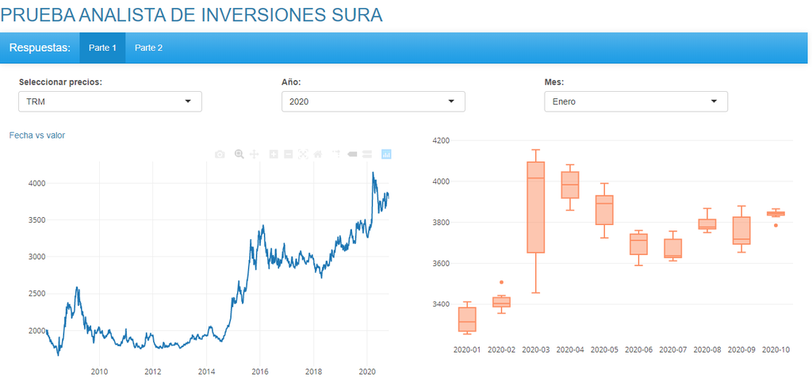

Imagen general

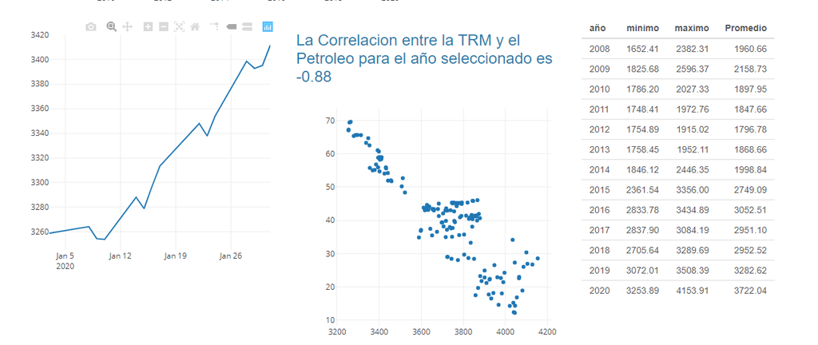

Y mediante el navebar podremos seleccionar le parte 2 donde seleccionamos algunas de las acciones mas importantes de S&P500

[figure not shown]

En este paso configuramos todos nuestros input reactivos configuramos nuestras graficas con la libreria seleccionada para hacer las graficas que fue ploty ejemplo:

bolsa <- reactive({ financial_data[(financial_data$ticker == input$accion) & (financial_data$año == input$yearx),]

output$finanza <- renderPlotly({ plot_ly(bolsa(), y = bolsa()$price.close , x = bolsa()$ref.date , type = ‘scatter’, mode = ‘lines’)

} )

En este ejemplo de codigo que se repite muchas veces seleccionamos un dataframe configurados por nuestros input y lo guardamos con la funcion bolsa() luego renderizamos nuestra grafica en ploty con el dataframe que se va creando a medida que el usuario marque cada una de las opciones disponible en este caso acciones y año